# ggplot

```r
library(ggplot2)
library(reshape2)
cars$color <- 1:50
cars$coche <- c("peugeot","ford")
```

Las partes habituales que ggplot utiliza para crear gráficos es la siguiente:

- Datos: solo admite tablas. No puedes pasar ni vectores ni listas ni nada extraño
- Estéticas, En un conjunto de datos hay columnas: edad, altura, ingresos, temperatura, etc. En un gráfico hay, en la terminología de ggplot2, estéticas. Se trata de caracteristicas que se asocian a los elementos que vamos a graficar (la posición x e y, el color, tamaño etc.).

Hay alrededor de una docena de esteticas, aunque se utilizan, generalmente, menos:

- x e y, distancias horizontal y vertical.
- colour, para el color.
- size, para el tamaño.
- shape, que indica la forma de los puntos (cuadrados, triángulos, etc.) de los puntos o del trazo (continuo, punteado) de las líneas.
- alpha para la transparencia: los valores más altos tendrían formas opacas y los más bajos, casi transparentes. De ahí la utilizad del canal alfa: da peso e importancia a las observaciones que la merecen.
- fill, para el color de relleno de las formas sólidas (barras, etc.).
- Geometrías (o capas): puntos, rectas, histogramas, densidades, etc. También se llaman capas porque pueden superponerse.

Opcionalmente pueden tener Facetas; que parten un gráfico en subgraficos preservando las escalas.

Por ejemplo:

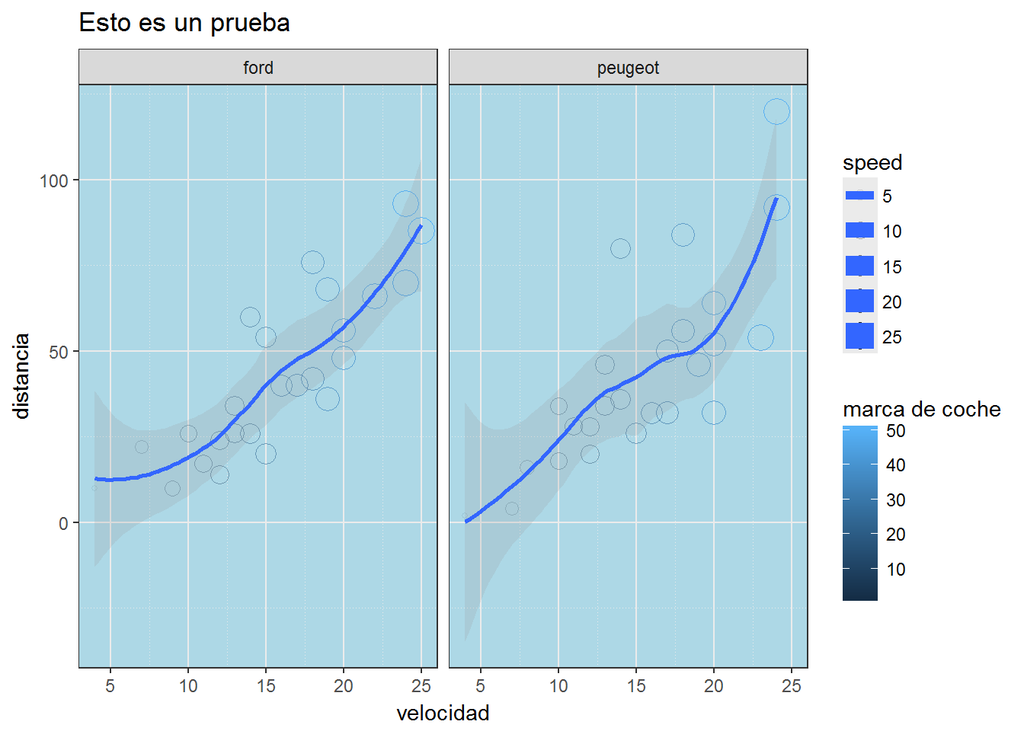

```r
ggplot(cars) + aes(x = speed, y = dist, colour = color, size = speed) +
           geom_point(shape = 1, aes(alpha = speed)) + geom_smooth(alpha = 0.2) +
           facet_grid( ~coche) +
         labs(x      = "velocidad",
              title  = "Esto es un prueba",
              y      = "distancia",
              colour = "marca de coche") + theme_bw()+
  theme(
    panel.background = element_rect(fill = "lightblue"),
    panel.grid.minor = element_line(linetype = "dotted")
  )
```

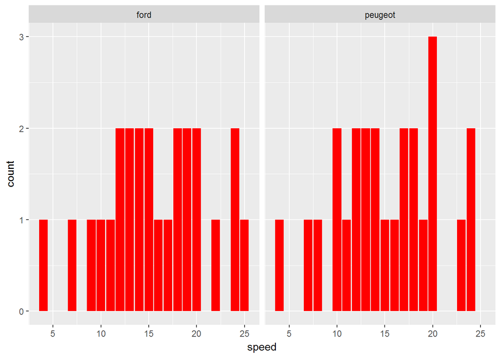

```r
ggplot(cars) + aes(x = speed) +
           geom_bar(fill = "red") +
           facet_wrap(~ coche)
```

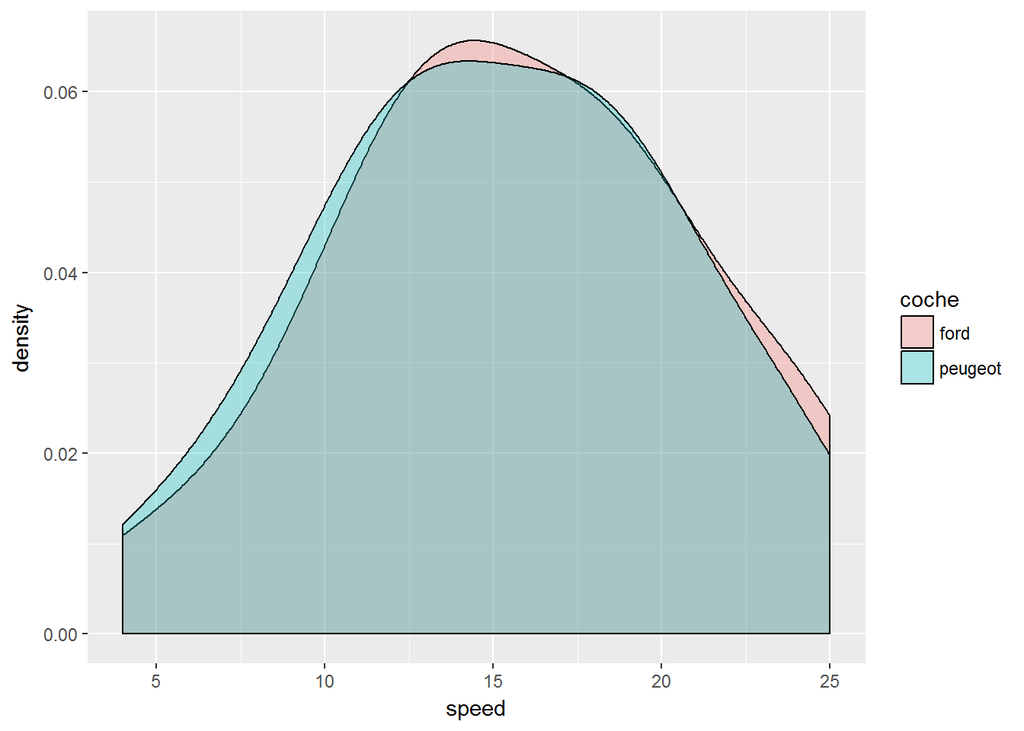

```r
ggplot(cars, aes(x = speed,fill = coche)) + geom_density(alpha = 0.3)
```

Una página que te ira bien es [esta.](https://ggplot2.tidyverse.org/reference/)